# Exploratory Data Analysis

Michal Sieczkos

24/02/2022

Importing necessary libraries

```r
library(ggplot2)
library(ggpubr)
library(validate)
library(tidyverse)
```

- The COVID data comes from John Hopkins University
- The data was collected between 22/01/2020 and 4/08/2021

Set working directory (if necessary)

```r
#setwd("path")
```

### Get the pre-processed data for Europe

```r
covid_eu <- read.csv("Europe COVID statistics.csv") # read the dataset

head(covid_eu)
```

```
##    X.1    X country iso3c       date confirmed deaths recovered new.d new.c
## 1 1513 1513 Albania   ALB 2020-01-22         0      0         0     0     0
## 2 1514 1514 Albania   ALB 2020-01-23         0      0         0     0     0
## 3 1515 1515 Albania   ALB 2020-01-24         0      0         0     0     0
## 4 1516 1516 Albania   ALB 2020-01-25         0      0         0     0     0
## 5 1517 1517 Albania   ALB 2020-01-26         0      0         0     0     0
## 6 1518 1518 Albania   ALB 2020-01-27         0      0         0     0     0
##   new.r population death_rate recovery_rate infection_rate continent
## 1     0    2877800          0             0              0        EU
## 2     0    2877800          0             0              0        EU
## 3     0    2877800          0             0              0        EU
## 4     0    2877800          0             0              0        EU
## 5     0    2877800          0             0              0        EU
## 6     0    2877800          0             0              0        EU
```

```r
dim(covid_eu)
```

```
## [1] 25245    16
```

```r
str(covid_eu)
```

```
## 'data.frame':    25245 obs. of  16 variables:
##  $ X.1           : int  1513 1514 1515 1516 1517 1518 1519 1520 1521 1522 ...
##  $ X             : int  1513 1514 1515 1516 1517 1518 1519 1520 1521 1522 ...
##  $ country       : chr  "Albania" "Albania" "Albania" "Albania" ...
##  $ iso3c         : chr  "ALB" "ALB" "ALB" "ALB" ...
##  $ date          : chr  "2020-01-22" "2020-01-23" "2020-01-24" "2020-01-25" ...
##  $ confirmed     : int  0 0 0 0 0 0 0 0 0 0 ...
##  $ deaths        : int  0 0 0 0 0 0 0 0 0 0 ...
##  $ recovered     : int  0 0 0 0 0 0 0 0 0 0 ...
##  $ new.d         : int  0 0 0 0 0 0 0 0 0 0 ...
##  $ new.c         : int  0 0 0 0 0 0 0 0 0 0 ...
##  $ new.r         : int  0 0 0 0 0 0 0 0 0 0 ...
##  $ population    : int  2877800 2877800 2877800 2877800 2877800 2877800 2877800 2877800 2877800 2877800 ...
##  $ death_rate    : num  0 0 0 0 0 0 0 0 0 0 ...
##  $ recovery_rate : num  0 0 0 0 0 0 0 0 0 0 ...
##  $ infection_rate: num  0 0 0 0 0 0 0 0 0 0 ...
##  $ continent     : chr  "EU" "EU" "EU" "EU" ...
```

```r
summary(covid_eu)
```

```
##       X.1               X            country             iso3c
##  Min.   :  1513   Min.   :  1513   Length:25245       Length:25245
##  1st Qu.: 36429   1st Qu.: 36429   Class :character   Class :character
##  Median : 63029   Median : 63029   Mode  :character   Mode  :character
##  Mean   : 67330   Mean   : 67330
##  3rd Qu.: 97945   3rd Qu.: 97945
##  Max.   :138153   Max.   :138153
##      date             confirmed           deaths         recovered
##  Length:25245       Min.   :      0   Min.   :     0   Min.   :      0
##  Class :character   1st Qu.:   2268   1st Qu.:    48   1st Qu.:    568
##  Mode  :character   Median :  42177   Median :   792   Median :  12596
##                     Mean   : 419116   Mean   : 10491   Mean   : 214377
##                     3rd Qu.: 278177   3rd Qu.:  8014   3rd Qu.: 129097
##                     Max.   :6274006   Max.   :159032   Max.   :5609682
##      new.d             new.c            new.r         population
##  Min.   :   0.00   Min.   :     0   Min.   :    0   Min.   :      809
##  1st Qu.:   0.00   1st Qu.:     9   1st Qu.:    0   1st Qu.:  1886202
##  Median :   3.00   Median :   195   Median :   17   Median :  5540718
##  Mean   :  45.21   Mean   :  2103   Mean   : 1113   Mean   : 16617720
##  3rd Qu.:  22.00   3rd Qu.:  1179   3rd Qu.:  443   3rd Qu.: 10708982
##  Max.   :1826.00   Max.   :117902   Max.   :70690   Max.   :145934460
##    death_rate       recovery_rate       infection_rate     continent
##  Min.   : 0.00000   Min.   :   0.0000   Min.   :  0.000   Length:25245
##  1st Qu.: 0.00000   1st Qu.:   0.0000   1st Qu.:  0.453   Class :character
##  Median : 0.04317   Median :   0.5143   Median :  4.261   Mode  :character
##  Mean   : 0.26533   Mean   :  10.5170   Mean   : 14.839
##  3rd Qu.: 0.29747   3rd Qu.:   8.9001   3rd Qu.: 18.375
##  Max.   :17.67930   Max.   :2883.5618   Max.   :865.266
```

```r
covid_eu$date <- as.Date(covid_eu$date) #convert the 'date' column from character representations to Date format

# Delete the unnecessary columns
covid_eu <- subset(covid_eu, select = -c(X.1, X, continent))
```

Creating another dataset to check for the correlation between the variables:

```r
covid_eu2 <- subset(covid_eu, select = -c(date, country, iso3c))

cor(covid_eu2)
```

```
##                   confirmed      deaths  recovered      new.d      new.c
## confirmed       1.000000000  0.95732964 0.69979199 0.49383721 0.57688275
## deaths          0.957329635  1.00000000 0.69759082 0.51576087 0.55936613
## recovered       0.699791987  0.69759082 1.00000000 0.43117855 0.33231815
## new.d           0.493837213  0.51576087 0.43117855 1.00000000 0.67113612
## new.c           0.576882752  0.55936613 0.33231815 0.67113612 1.00000000
## new.r           0.446241158  0.43350983 0.61881213 0.59813303 0.49869532
## population      0.596974543  0.63041896 0.53612829 0.53639511 0.50763766
## death_rate      0.085970918  0.08530009 0.07913909 0.38181959 0.22957300
## recovery_rate  -0.003404238 -0.01510055 0.05612705 0.06044195 0.04657991
## infection_rate  0.090972116  0.05730300 0.01409522 0.18140058 0.37224450
##                    new.r   population  death_rate recovery_rate infection_rate
## confirmed      0.4462412  0.596974543 0.085970918  -0.003404238     0.09097212
## deaths         0.4335098  0.630418955 0.085300091  -0.015100549     0.05730300
## recovered      0.6188121  0.536128291 0.079139086   0.056127053     0.01409522
## new.d          0.5981330  0.536395112 0.381819587   0.060441950     0.18140058
## new.c          0.4986953  0.507637655 0.229573001   0.046579913     0.37224450
## new.r          1.0000000  0.485977304 0.227287335   0.282220560     0.15761075
## population     0.4859773  1.000000000 0.007234253  -0.065672641    -0.04905370
## death_rate     0.2272873  0.007234253 1.000000000   0.310355024     0.49238632
## recovery_rate  0.2822206 -0.065672641 0.310355024   1.000000000     0.38123024
## infection_rate 0.1576108 -0.049053697 0.492386318   0.381230245     1.00000000
```

The results shown that the variables of ‘new.c’, ‘new.r’ and ‘population’ all have correlation score higher than 0.5 (0.67, 0.598 and 0.536 respectively), which could indicate possible relationship between the variables, thus worth including in prediction models.

### Investigate the countries data

```r
# Final infections (as a sum)
covid_eu$country <- as.factor(covid_eu$country)
covid_cases <- covid_eu[covid_eu$date == "2021-08-04",] # get the total values for each country (last day the data was gathered is 4-08-2021)

head(covid_cases)
```

```
##                     country iso3c       date confirmed deaths recovered new.d
## 561                 Albania   ALB 2021-08-04    133310   2457    130314     0
## 1122                Andorra   AND 2021-08-04     14797    128     14380     0
## 1683                Austria   AUT 2021-08-04    660854  10744    644388     2
## 2244                Belgium   BEL 2021-08-04   1132934  25258         0     7
## 2805               Bulgaria   BGR 2021-08-04    426432  18229    398721     4
## 3366 Bosnia and Herzegovina   BIH 2021-08-04    205949   9689    189710     0
##      new.c new.r population death_rate recovery_rate infection_rate
## 561     99    23    2877800 0.00000000     0.7992216       3.440128
## 1122    31    32      77265 0.00000000    41.4159063      40.121659
## 1683   592   350    9006400 0.02220643     3.8861254       6.573104
## 2244  2176     0   11492641 0.06090854     0.0000000      18.933855
## 2805   429    52    6948445 0.05756684     0.7483689       6.174043
## 3366   124    13    3280815 0.00000000     0.3962430       3.779549
```

```r
summary(covid_cases)
```

```
##                    country      iso3c                date
##  Albania               : 1   Length:45          Min.   :2021-08-04
##  Andorra               : 1   Class :character   1st Qu.:2021-08-04
##  Austria               : 1   Mode  :character   Median :2021-08-04
##  Belarus               : 1                      Mean   :2021-08-04
##  Belgium               : 1                      3rd Qu.:2021-08-04
##  Bosnia and Herzegovina: 1                      Max.   :2021-08-04
##  (Other)               :39
##    confirmed           deaths         recovered           new.d
##  Min.   :     27   Min.   :     0   Min.   :      0   Min.   :  0.0
##  1st Qu.: 133310   1st Qu.:  1273   1st Qu.:  24693   1st Qu.:  0.0
##  Median : 364244   Median :  7129   Median : 150376   Median :  2.0
##  Mean   :1168074   Mean   : 25295   Mean   : 621915   Mean   : 27.4
##  3rd Qu.:1102829   3rd Qu.: 25258   3rd Qu.: 415111   3rd Qu.:  9.0
##  Max.   :6274006   Max.   :159032   Max.   :5609682   Max.   :769.0
##
##      new.c           new.r           population          death_rate
##  Min.   :    0   Min.   :    0.0   Min.   :      809   Min.   :0.00000
##  1st Qu.:  120   1st Qu.:    0.0   1st Qu.:  1886202   1st Qu.:0.00000
##  Median :  429   Median :   52.0   Median :  5540718   Median :0.03127
##  Mean   : 3048   Mean   :  758.7   Mean   : 16617720   Mean   :0.07946
##  3rd Qu.: 1217   3rd Qu.:  293.0   3rd Qu.: 10708982   3rd Qu.:0.12395
##  Max.   :29241   Max.   :19545.0   Max.   :145934460   Max.   :0.52695
##
##  recovery_rate    infection_rate
##  Min.   : 0.000   Min.   : 0.000
##  1st Qu.: 0.000   1st Qu.: 4.859
##  Median : 1.033   Median :10.899
##  Mean   : 7.107   Mean   :16.275
##  3rd Qu.: 6.539   3rd Qu.:24.647
##  Max.   :66.359   Max.   :49.530
##
```

Population of the countries:

```r
eu_pop <- covid_cases$population

head(eu_pop)
```

```
## [1]  2877800    77265  9006400 11492641  6948445  3280815
```

```r
summary(eu_pop)
```

```
##      Min.   1st Qu.    Median      Mean   3rd Qu.      Max.
##       809   1886202   5540718  16617720  10708982 145934460
```

```r
#Infection rate (cases vs population)
covid_inf_rate <- (covid_cases$confirmed/covid_cases$population)*100

head(covid_inf_rate)
```

```
## [1]  4.632358 19.150974  7.337604  9.857908  6.137085  6.277373
```

```r
summary(covid_inf_rate)
```

```
##    Min. 1st Qu.  Median    Mean 3rd Qu.    Max.
##   1.987   5.635   7.834   8.299   9.858  19.151
```

Checking whether every country has the same amount of days, from which data have been collected:

```r
covid_eu$iso3c <- as.factor(covid_eu$iso3c)
summary(covid_eu$iso3c)
```

```
## ALB AND AUT BEL BGR BIH BLR CHE CYP CZE DEU DNK ESP EST FIN FRA GBR GRC HRV HUN
## 561 561 561 561 561 561 561 561 561 561 561 561 561 561 561 561 561 561 561 561
## IRL ISL ITA LIE LTU LUX LVA MCO MDA MKD MLT MNE NLD NOR POL PRT ROU RUS SMR SRB
## 561 561 561 561 561 561 561 561 561 561 561 561 561 561 561 561 561 561 561 561
## SVK SVN SWE UKR VAT
## 561 561 561 561 561
```

```r
summary(covid_eu$country)
```

```
##                Albania                Andorra                Austria
##                    561                    561                    561
##                Belarus                Belgium Bosnia and Herzegovina
##                    561                    561                    561
##               Bulgaria                Croatia                 Cyprus
##                    561                    561                    561
##                Czechia                Denmark                Estonia
##                    561                    561                    561
##                Finland                 France                Germany
##                    561                    561                    561
##                 Greece               Holy See                Hungary
##                    561                    561                    561
##                Iceland                Ireland                  Italy
##                    561                    561                    561
##                 Latvia          Liechtenstein              Lithuania
##                    561                    561                    561
##             Luxembourg                  Malta                Moldova
##                    561                    561                    561
##                 Monaco             Montenegro            Netherlands
##                    561                    561                    561
##        North Macedonia                 Norway                 Poland
##                    561                    561                    561
##               Portugal                Romania                 Russia
##                    561                    561                    561
##             San Marino                 Serbia               Slovakia
##                    561                    561                    561
##               Slovenia                  Spain                 Sweden
##                    561                    561                    561
##            Switzerland                Ukraine         United Kingdom
##                    561                    561                    561
```

Bar plot for cases in the European countries:

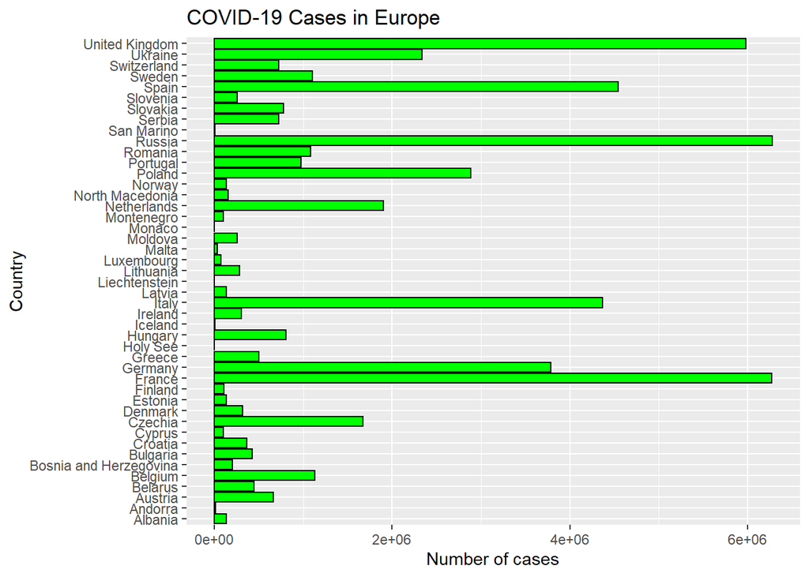

```r
eu_cases <- ggplot(data = covid_cases, aes(x = confirmed, y = country)) + geom_bar(stat = "identity", fill = "green" , color = "black") + labs(x = "Number of cases", y = "Country", title = "COVID-19 Cases in Europe") + theme_gray()
eu_cases
```

Bar plot for deaths in the European countries:

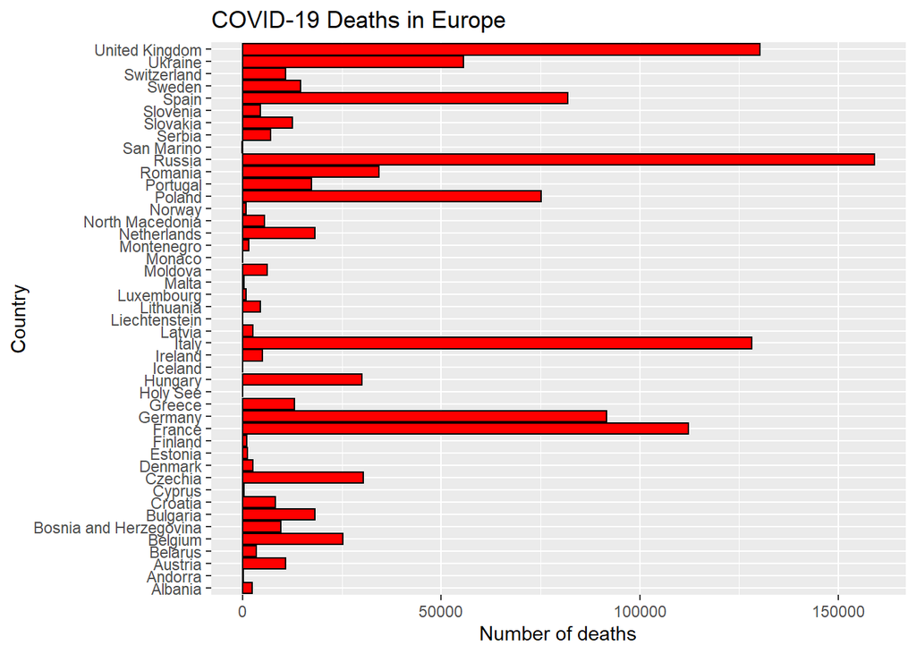

```r
#e <- ggplot(data = covid_4aug21, aes(confirmed)) + geom_bar(stat = "count", color = "red") + theme_light()

eu_deaths <- ggplot(data = covid_cases, aes(x = deaths, y = country)) + geom_bar(stat = "identity", fill = "red", colour = "black") + labs(x = "Number of deaths", y = "Country", title = "COVID-19 Deaths in Europe") + theme_gray()
eu_deaths
```

European countries population plot:

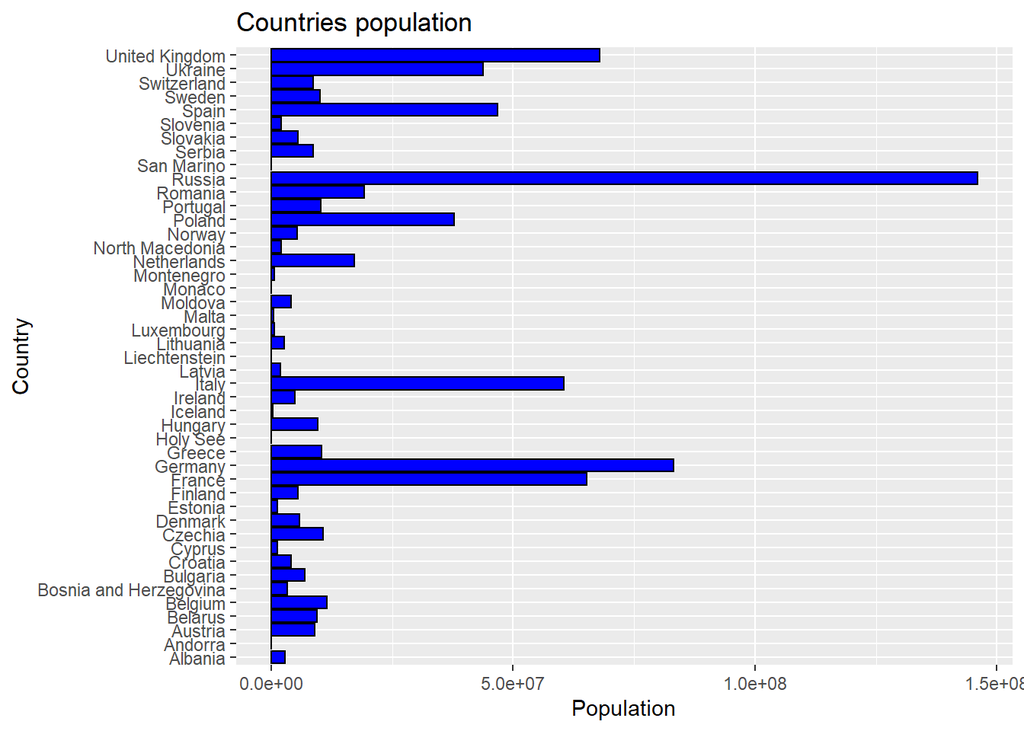

```r
pop <- ggplot(data = covid_cases, aes(x = population, y = country)) + geom_bar(stat = "identity", fill = "blue", colour = "black") + labs(x = "Population", y = "Country", title = "Countries population") + theme_gray()
pop
```

Taking a closer look at the UK data:

```r
# Get the UK data
covid_gbr = covid_eu[covid_eu$iso3c == "GBR",]
head(covid_gbr)
```

```
##             country iso3c       date confirmed deaths recovered new.d new.c
## 8977 United Kingdom   GBR 2020-01-22         0      0         0     0     0
## 8978 United Kingdom   GBR 2020-01-23         0      0         0     0     0
## 8979 United Kingdom   GBR 2020-01-24         0      0         0     0     0
## 8980 United Kingdom   GBR 2020-01-25         0      0         0     0     0
## 8981 United Kingdom   GBR 2020-01-26         0      0         0     0     0
## 8982 United Kingdom   GBR 2020-01-27         0      0         0     0     0
##      new.r population death_rate recovery_rate infection_rate
## 8977     0   67886004          0             0              0
## 8978     0   67886004          0             0              0
## 8979     0   67886004          0             0              0
## 8980     0   67886004          0             0              0
## 8981     0   67886004          0             0              0
## 8982     0   67886004          0             0              0
```

```r
summary(covid_gbr)
```

```
##            country        iso3c          date              confirmed
##  United Kingdom:561   GBR    :561   Min.   :2020-01-22   Min.   :      0
##  Albania       :  0   ALB    :  0   1st Qu.:2020-06-10   1st Qu.: 269097
##  Andorra       :  0   AND    :  0   Median :2020-10-28   Median : 945369
##  Austria       :  0   AUT    :  0   Mean   :2020-10-28   Mean   :1997794
##  Belarus       :  0   BEL    :  0   3rd Qu.:2021-03-17   3rd Qu.:4287993
##  Belgium       :  0   BGR    :  0   Max.   :2021-08-04   Max.   :5980830
##  (Other)       :  0   (Other):  0
##      deaths         recovered         new.d            new.c
##  Min.   :     0   Min.   :    0   Min.   :   0.0   Min.   :    0
##  1st Qu.: 39108   1st Qu.: 1269   1st Qu.:  12.0   1st Qu.: 1188
##  Median : 45765   Median : 2775   Median :  57.0   Median : 4115
##  Mean   : 66935   Mean   : 6146   Mean   : 232.3   Mean   :10674
##  3rd Qu.:126068   3rd Qu.:12053   3rd Qu.: 347.0   3rd Qu.:16994
##  Max.   :130298   Max.   :24693   Max.   :1826.0   Max.   :68196
##
##      new.r           population         death_rate      recovery_rate
##  Min.   :   0.00   Min.   :67886004   Min.   :0.00000   Min.   :0.000000
##  1st Qu.:   2.00   1st Qu.:67886004   1st Qu.:0.01768   1st Qu.:0.002946
##  Median :  11.00   Median :67886004   Median :0.08396   Median :0.016204
##  Mean   :  44.61   Mean   :67886004   Mean   :0.34213   Mean   :0.065718
##  3rd Qu.:  44.00   3rd Qu.:67886004   3rd Qu.:0.51115   3rd Qu.:0.064814
##  Max.   :1736.00   Max.   :67886004   Max.   :2.68980   Max.   :2.557228
##
##  infection_rate
##  Min.   :  0.000
##  1st Qu.:  1.750
##  Median :  6.062
##  Mean   : 15.723
##  3rd Qu.: 25.033
##  Max.   :100.457
##
```

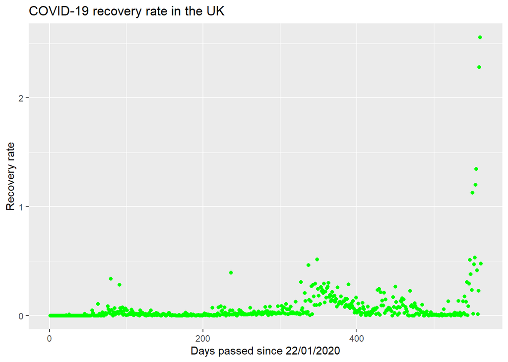

```r
# Recovery rate
gbr_recov_rate <- ggplot(data = covid_gbr, aes(c(1:561), recovery_rate)) + geom_point(color = "green") + labs(x = "Days passed since 22/01/2020", y = "Recovery rate", title = "COVID-19 recovery rate in the UK")
gbr_recov_rate
```

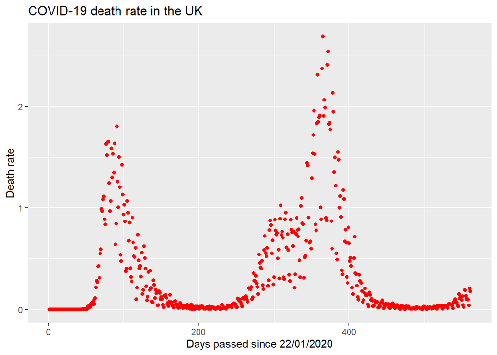

```r
# Death rate
gbr_death_rate <- ggplot(data = covid_gbr, aes(c(1:561), death_rate)) + geom_point(color = "red") + labs(x = "Days passed since 22/01/2020", y = "Death rate", title = "COVID-19 death rate in the UK")
gbr_death_rate
```

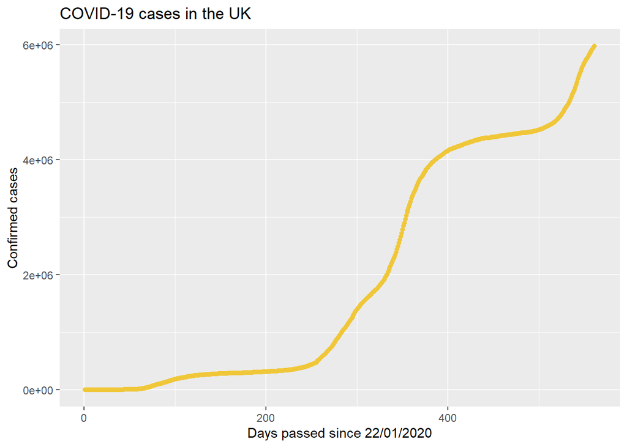

```r
# Total cases
gbr_cases <- ggplot(data = covid_gbr, aes(c(1:561), confirmed)) + geom_point(color = "#f0c739") + labs(x = "Days passed since 22/01/2020", y = "Confirmed cases", title = "COVID-19 cases in the UK")
gbr_cases
```

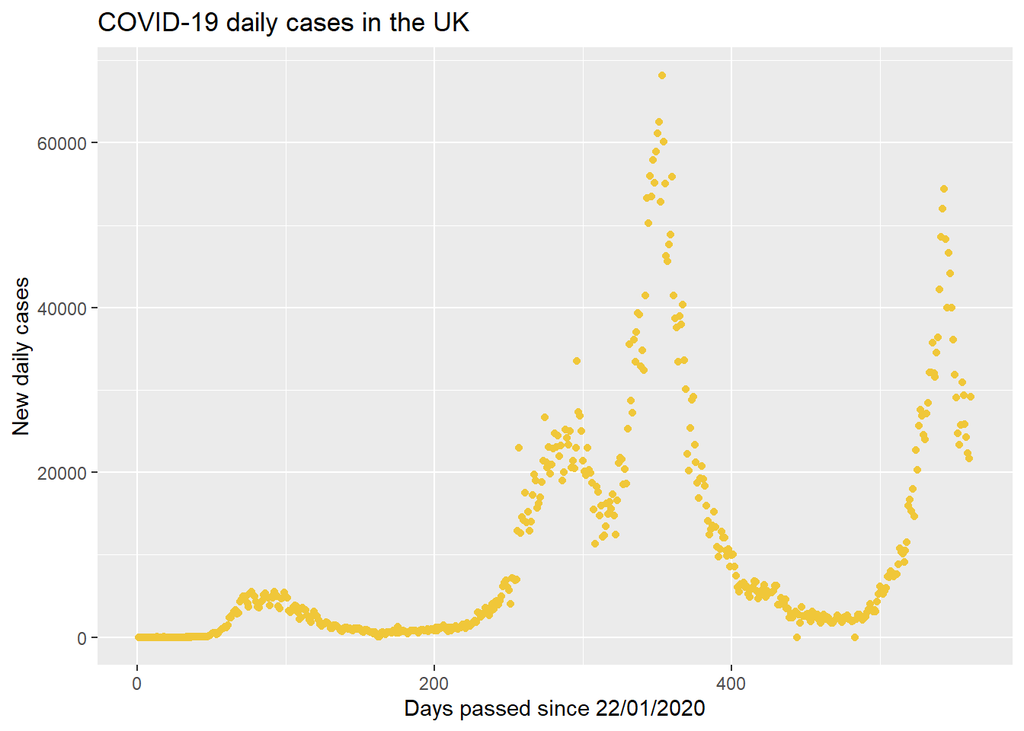

```r
# Daily cases
gbr_new_c <- ggplot(data = covid_gbr, aes(c(1:561), new.c)) + geom_point(color = "#f0c739") + labs(x = "Days passed since 22/01/2020", y = "New daily cases", title = "COVID-19 daily cases in the UK")
gbr_new_c
```

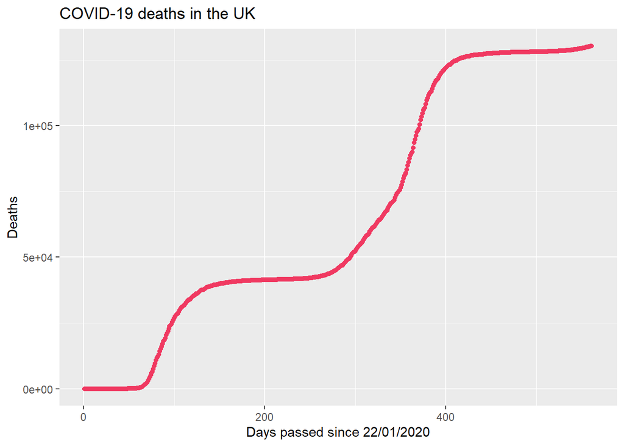

```r
# Total deaths
gbr_deaths <- ggplot(data = covid_gbr, aes(c(1:561), deaths)) + geom_point(color = "#f03961") + labs(x = "Days passed since 22/01/2020", y = "Deaths", title = "COVID-19 deaths in the UK")
gbr_deaths
```

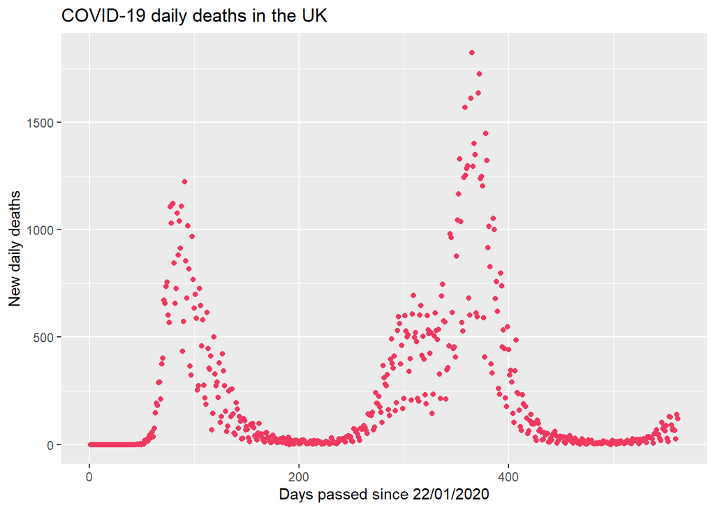

```r
# Daily deaths
gbr_new_d <- ggplot(data = covid_gbr, aes(c(1:561), new.d)) + geom_point(color = "#f03961") + labs(x = "Days passed since 22/01/2020", y = "New daily deaths", title = "COVID-19 daily deaths in the UK")
gbr_new_d
```

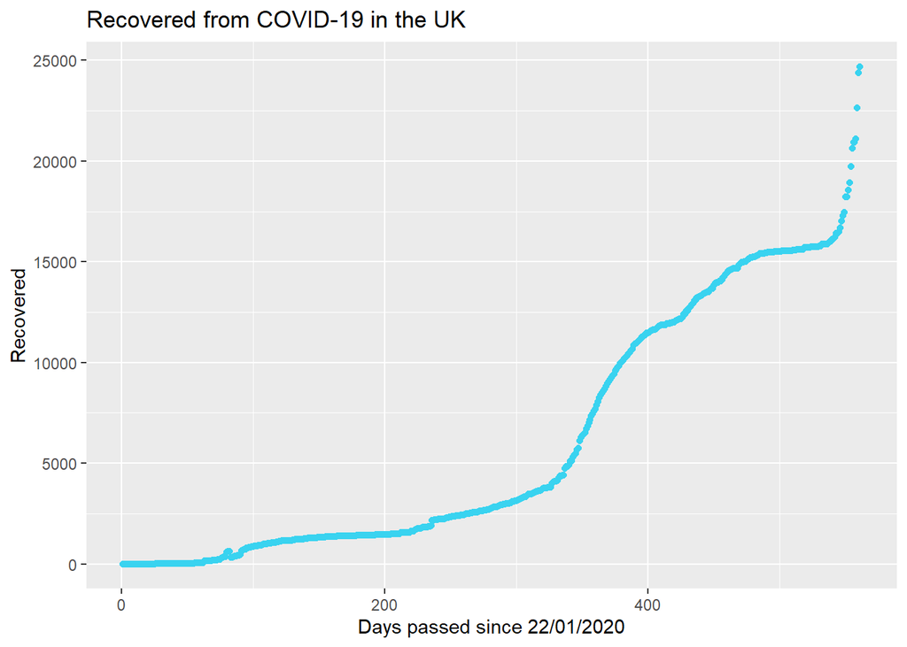

```r
# Total recovered
gbr_recovered <- ggplot(data = covid_gbr, aes(c(1:561), recovered)) + geom_point(color = "#39d3f0") + labs(x = "Days passed since 22/01/2020", y = "Recovered", title = "Recovered from COVID-19 in the UK")
gbr_recovered
```

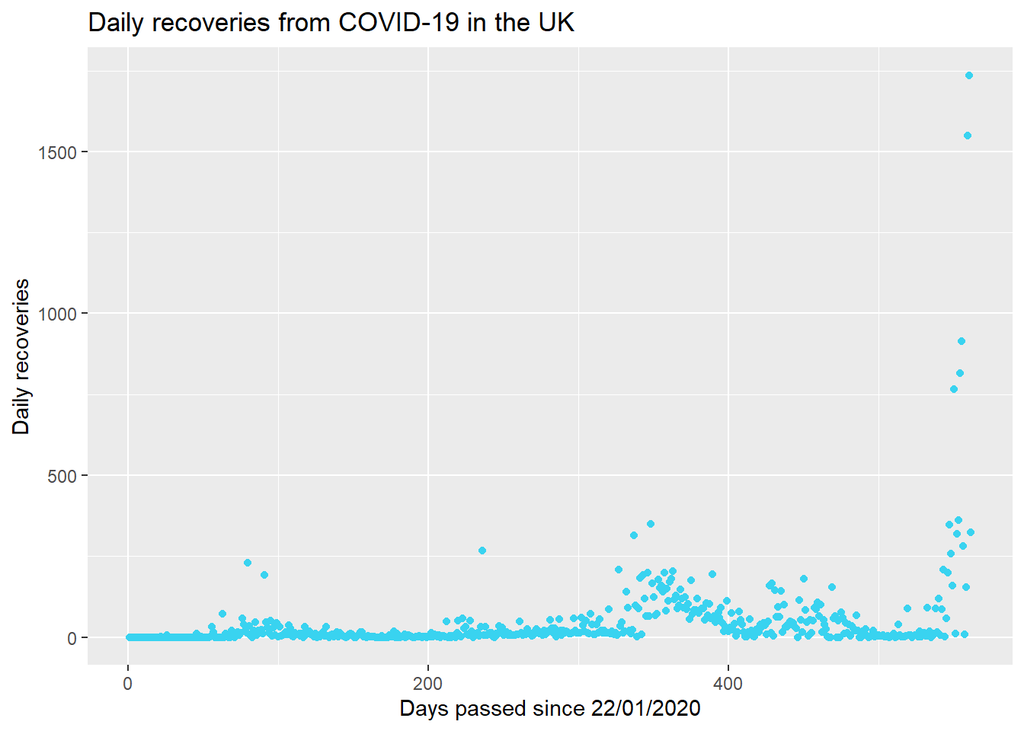

```r
# Daily recovered
gbr_new_r <- ggplot(data = covid_gbr, aes(c(1:561), new.r)) + geom_point(color = "#39d3f0") + labs(x = "Days passed since 22/01/2020", y = "Daily recoveries", title = "Daily recoveries from COVID-19 in the UK")
gbr_new_r
```

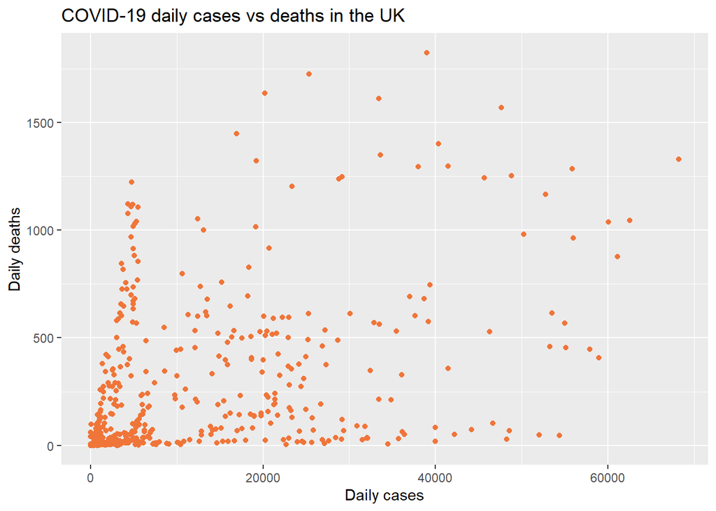

```r
# Daily cases vs deaths
gbr_daily_cd <- ggplot(data = covid_gbr, aes(new.c, new.d)) + geom_point(color = "#f07539") + labs(x = "Daily cases", y = "Daily deaths", title = "COVID-19 daily cases vs deaths in the UK")
gbr_daily_cd
```

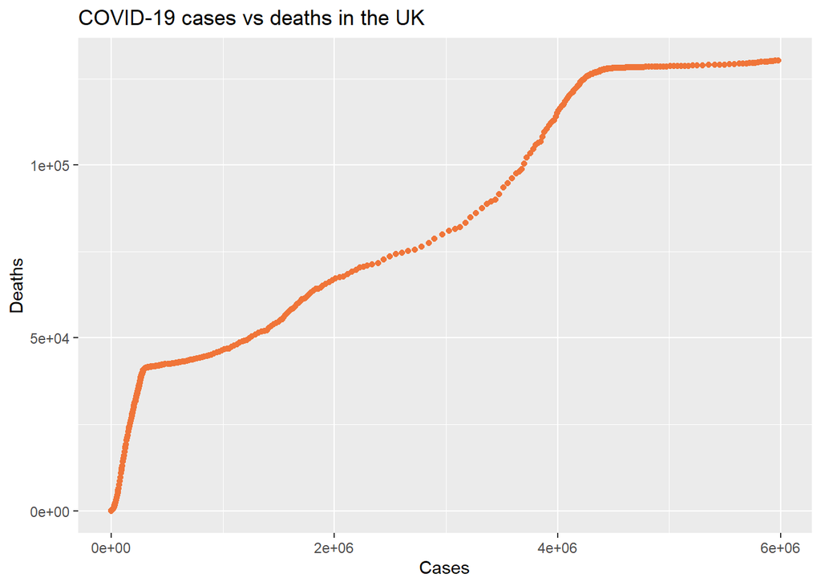

```r
# Total cases vs deaths
gbr_cd <- ggplot(data = covid_gbr, aes(confirmed, deaths)) + geom_point(color = "#f07539") + labs(x = "Cases", y = "Deaths", title = "COVID-19 cases vs deaths in the UK")
gbr_cd
```

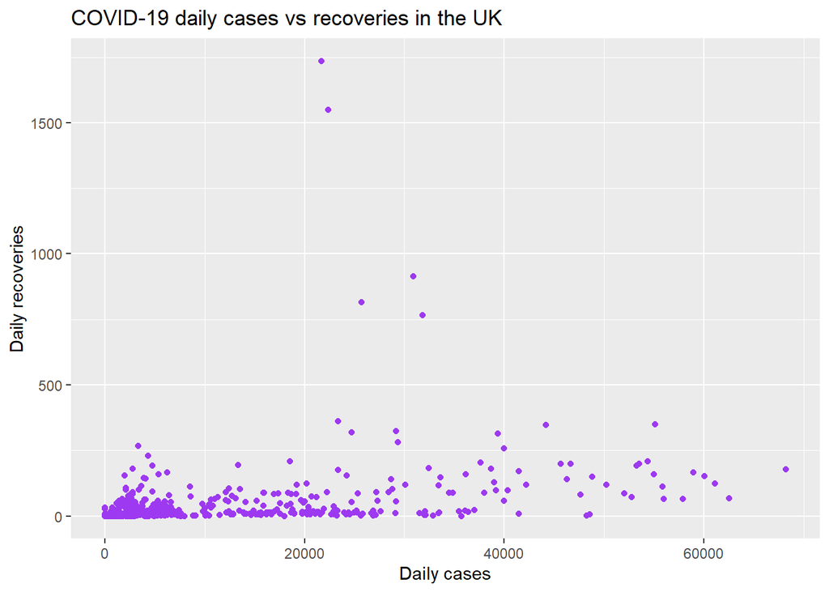

```r
# Daily cases vs recovered
gbr_daily_cr <- ggplot(data = covid_gbr, aes(new.c, new.r)) + geom_point(color = "#9d39f0") + labs(x = "Daily cases", y = "Daily recoveries", title = "COVID-19 daily cases vs recoveries in the UK")
gbr_daily_cr
```

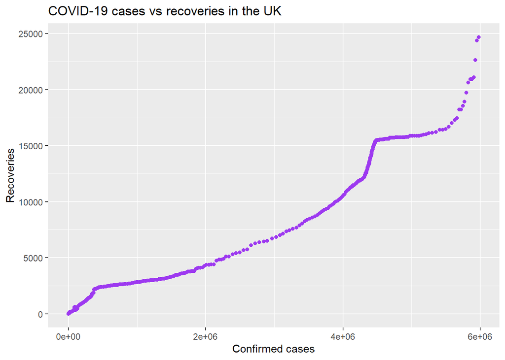

```r
# Total cases vs recovered
gbr_cr <- ggplot(data = covid_gbr, aes(confirmed, recovered)) + geom_point(color = "#9d39f0") + labs(x = "Confirmed cases", y = "Recoveries", title = "COVID-19 cases vs recoveries in the UK")
gbr_cr
```

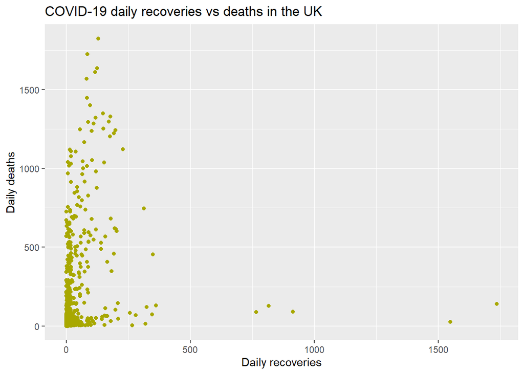

```r
# Daily recovered vs deaths
gbr_daily_rd <- ggplot(data = covid_gbr, aes(new.r, new.d)) + geom_point(color = "#a8a800") + labs(x = "Daily recoveries", y = "Daily deaths", title = "COVID-19 daily recoveries vs deaths in the UK")
gbr_daily_rd
```

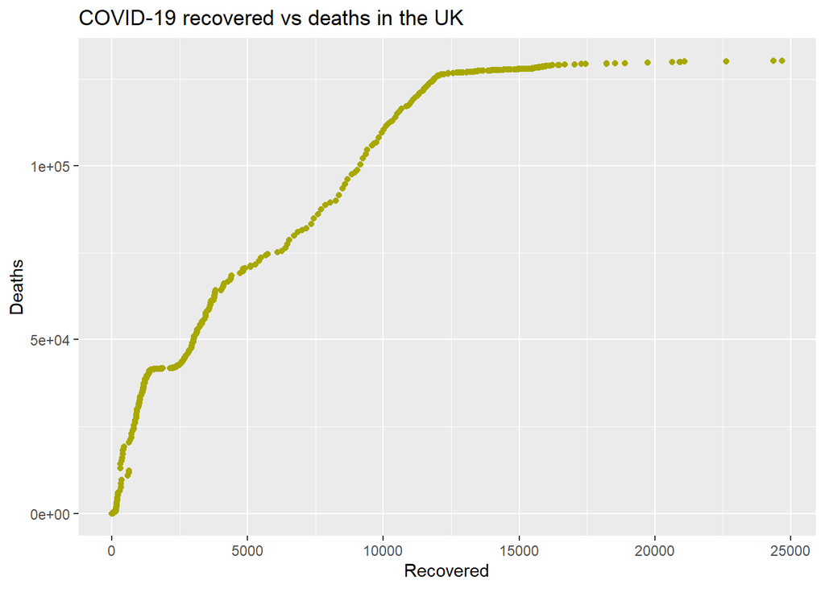

```r
# Total recovered vs deaths
gbr_rd <- ggplot(data = covid_gbr, aes(recovered, deaths)) + geom_point(color = "#a8a800") + labs(x = "Recovered", y = "Deaths", title = "COVID-19 recovered vs deaths in the UK")
gbr_rd
```

Arranging the plots and saving externally:

```
## $`1`
```

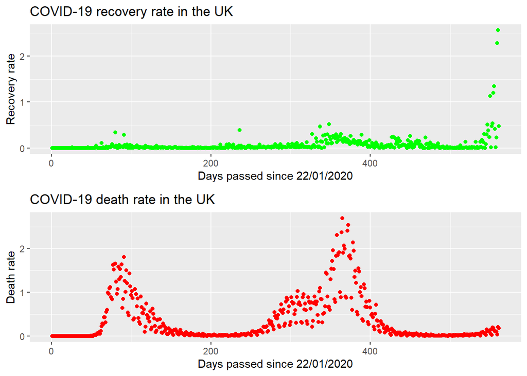

```
##
## $`2`
```

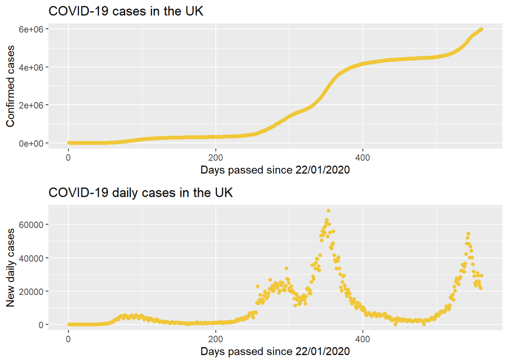

```
##
## $`3`
```

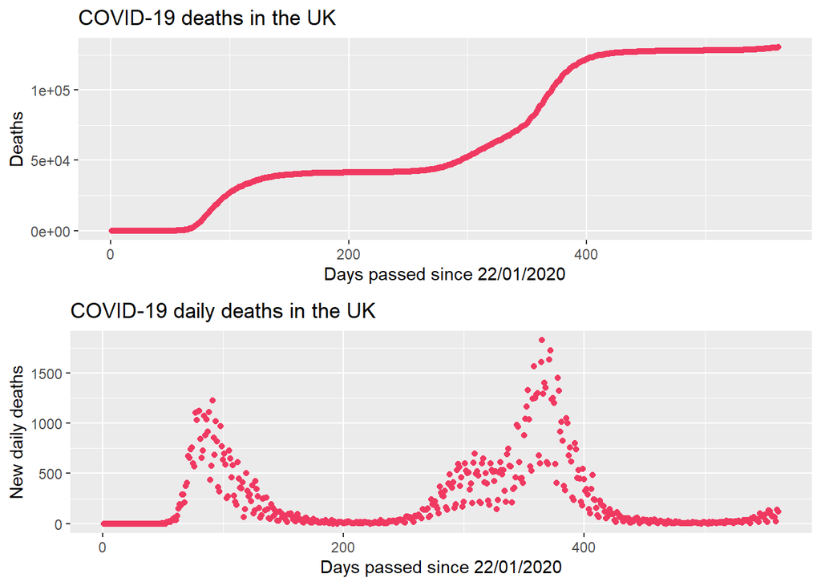

```
##
## $`4`
```

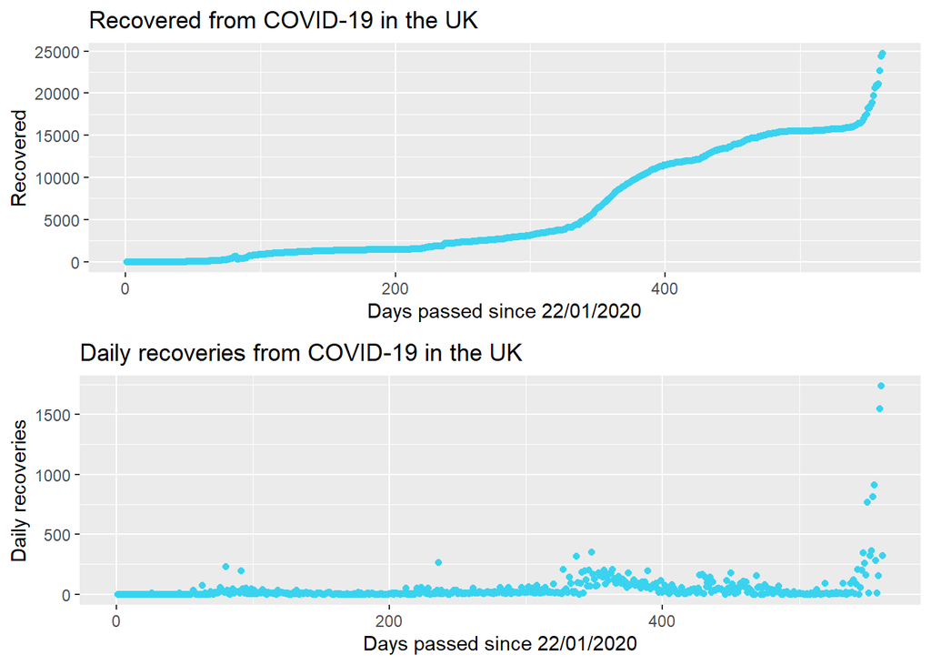

```
##
## $`5`
```

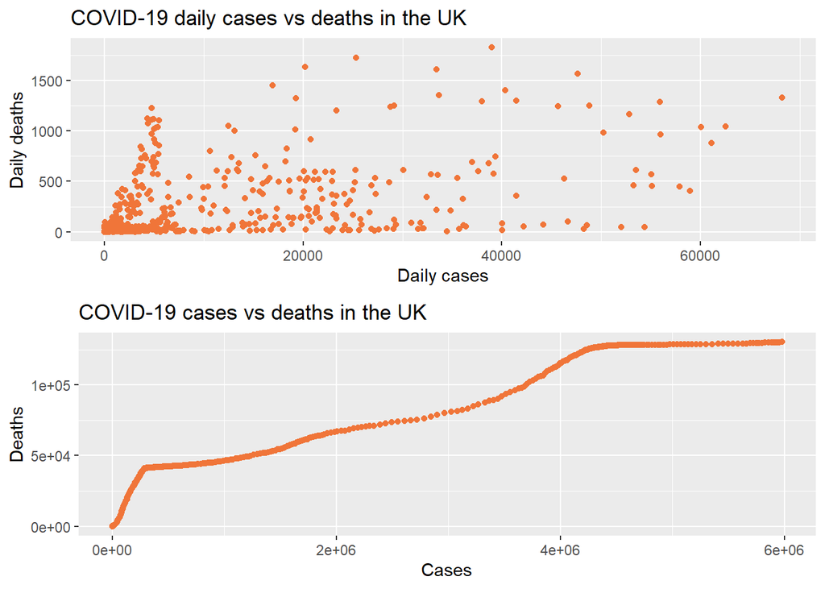

```
##
## $`6`
```

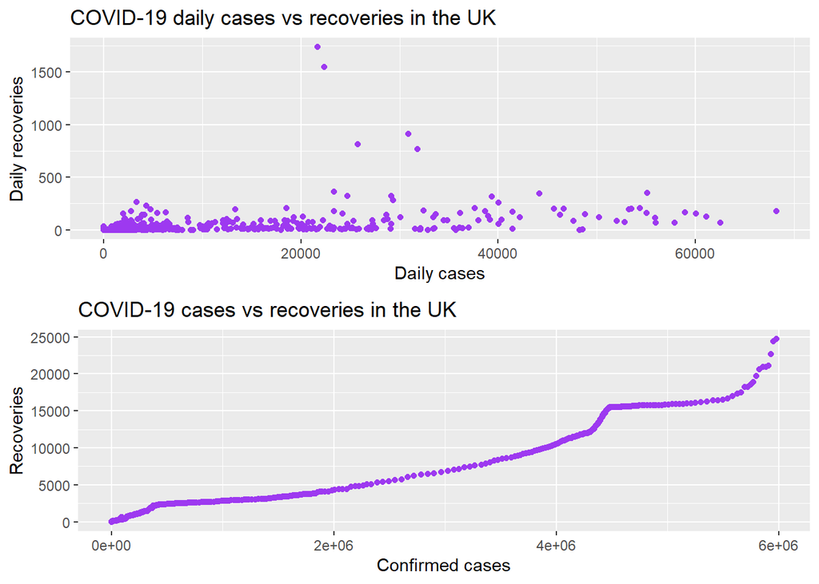

```
##
## $`7`
```

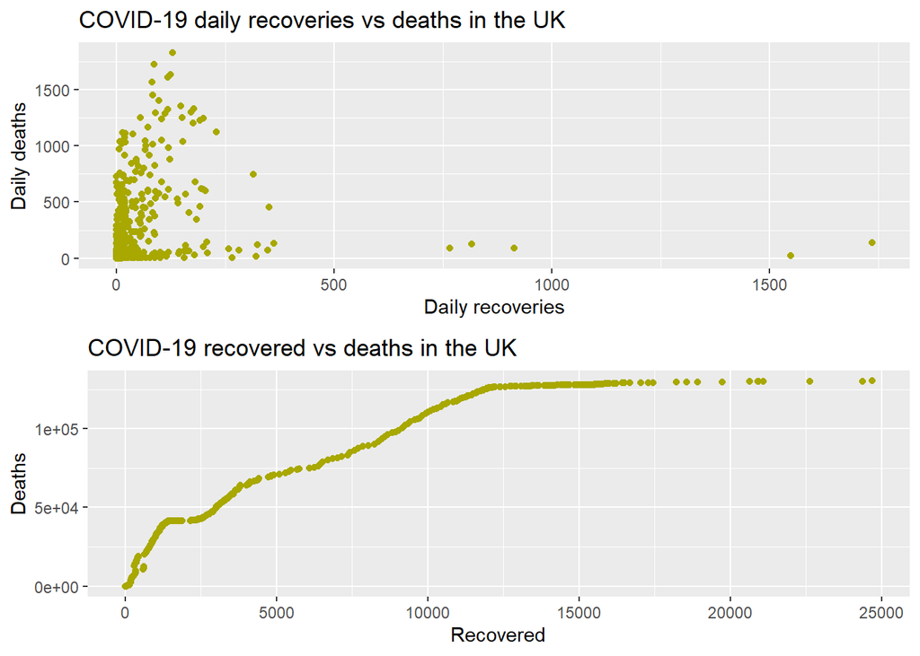

```
##
## attr(,"class")
## [1] "list"      "ggarrange"
```

```r
uk_plots <- ggarrange(gbr_recov_rate, gbr_death_rate, gbr_cases, gbr_new_c, gbr_deaths, gbr_new_d, gbr_recovered, gbr_new_r, gbr_daily_cd, gbr_cd, gbr_daily_cr, gbr_cr, gbr_daily_rd, gbr_rd, ncol = 1, nrow = 2)
uk_plots
```

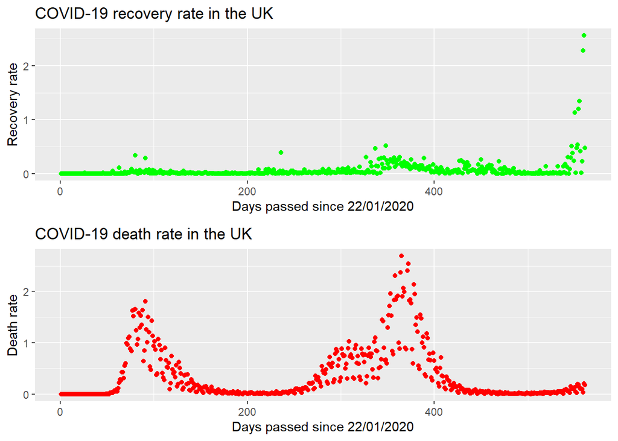

```r
uk_plots[[1]] #Visualize the page 1 (just to check)
```

```r
ggexport(uk_plots, filename = "UK_plots.pdf") # Save the plots into PDF file
```

```
## file saved to UK_plots.pdf
```

Focusing on countries with bottom top10 population (from 6th to 10th most populated)

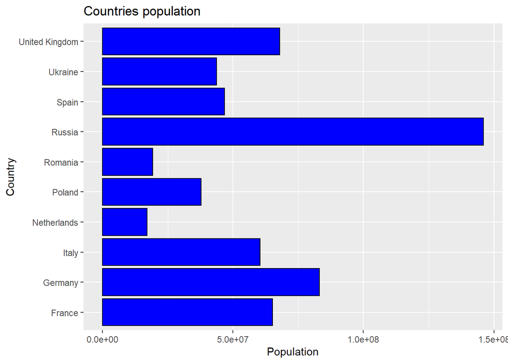

```r
# Get the top 5 countries with the most population
countries_pop <- covid_cases[covid_cases$population > 15000000,]

#countries_pop <- sort(countries_pop$population, decreasing = TRUE)
# countries_pop <- within(countries_pop, population <- sort(countries_pop$population, decreasing = TRUE))

pop_top5 <- ggplot(data = countries_pop, aes(x = population, y = country)) + geom_bar(stat = "identity", fill = "blue", colour = "black") + labs(x = "Population", y = "Country", title = "Countries population") + theme_gray()
pop_top5
```

### Analysing the top6-10 countries (Spain, Poland, Romania, Ukraine, Netherlands)

Top6-10 countries in terms of population is the area of focus in this case, whereas top5 is only analysed briefly (it has been assigned for detailed analysis to other member of the group)

```r
# Get the data for Spain
covid_esp = covid_eu[covid_eu$iso3c == "ESP",]
head(covid_esp)
```

```
##      country iso3c       date confirmed deaths recovered new.d new.c new.r
## 6733   Spain   ESP 2020-01-22         0      0         0     0     0     0
## 6734   Spain   ESP 2020-01-23         0      0         0     0     0     0
## 6735   Spain   ESP 2020-01-24         0      0         0     0     0     0
## 6736   Spain   ESP 2020-01-25         0      0         0     0     0     0
## 6737   Spain   ESP 2020-01-26         0      0         0     0     0     0
## 6738   Spain   ESP 2020-01-27         0      0         0     0     0     0
##      population death_rate recovery_rate infection_rate
## 6733   46754783          0             0              0
## 6734   46754783          0             0              0
## 6735   46754783          0             0              0
## 6736   46754783          0             0              0
## 6737   46754783          0             0              0
## 6738   46754783          0             0              0
```

```r
summary(covid_esp)
```

```
##     country        iso3c          date              confirmed
##  Spain  :561   ESP    :561   Min.   :2020-01-22   Min.   :      0
##  Albania:  0   ALB    :  0   1st Qu.:2020-06-10   1st Qu.: 242280
##  Andorra:  0   AND    :  0   Median :2020-10-28   Median :1136503
##  Austria:  0   AUT    :  0   Mean   :2020-10-28   Mean   :1628970
##  Belarus:  0   BEL    :  0   3rd Qu.:2021-03-17   3rd Qu.:3206116
##  Belgium:  0   BGR    :  0   Max.   :2021-08-04   Max.   :4545184
##  (Other):  0   (Other):  0
##      deaths        recovered          new.d            new.c
##  Min.   :    0   Min.   :     0   Min.   :   0.0   Min.   :    0
##  1st Qu.:27563   1st Qu.:150376   1st Qu.:   0.0   1st Qu.:    0
##  Median :35466   Median :150376   Median :  34.0   Median : 3632
##  Mean   :43640   Mean   :126887   Mean   : 149.3   Mean   : 8253
##  3rd Qu.:72793   3rd Qu.:150376   3rd Qu.: 217.0   3rd Qu.:10814
##  Max.   :81844   Max.   :150376   Max.   :1623.0   Max.   :93822
##
##      new.r          population         death_rate      recovery_rate
##  Min.   :   0.0   Min.   :46754783   Min.   :0.00000   Min.   : 0.0000
##  1st Qu.:   0.0   1st Qu.:46754783   1st Qu.:0.00000   1st Qu.: 0.0000
##  Median :   0.0   Median :46754783   Median :0.07272   Median : 0.0000
##  Mean   : 268.1   Mean   :46754783   Mean   :0.31935   Mean   : 0.5733
##  3rd Qu.:   0.0   3rd Qu.:46754783   3rd Qu.:0.46412   3rd Qu.: 0.0000
##  Max.   :6399.0   Max.   :46754783   Max.   :3.47130   Max.   :13.6863
##
##  infection_rate
##  Min.   :  0.000
##  1st Qu.:  0.000
##  Median :  7.768
##  Mean   : 17.652
##  3rd Qu.: 23.129
##  Max.   :200.668
##
```

```r
# Get the data for Poland
covid_pol = covid_eu[covid_eu$iso3c == "POL",]
head(covid_pol)
```

```
##       country iso3c       date confirmed deaths recovered new.d new.c new.r
## 19075  Poland   POL 2020-01-22         0      0         0     0     0     0
## 19076  Poland   POL 2020-01-23         0      0         0     0     0     0
## 19077  Poland   POL 2020-01-24         0      0         0     0     0     0
## 19078  Poland   POL 2020-01-25         0      0         0     0     0     0
## 19079  Poland   POL 2020-01-26         0      0         0     0     0     0
## 19080  Poland   POL 2020-01-27         0      0         0     0     0     0
##       population death_rate recovery_rate infection_rate
## 19075   37846605          0             0              0
## 19076   37846605          0             0              0
## 19077   37846605          0             0              0
## 19078   37846605          0             0              0
## 19079   37846605          0             0              0
## 19080   37846605          0             0              0
```

```r
summary(covid_pol)
```

```
##     country        iso3c          date              confirmed
##  Poland :561   POL    :561   Min.   :2020-01-22   Min.   :      0
##  Albania:  0   ALB    :  0   1st Qu.:2020-06-10   1st Qu.:  27842
##  Andorra:  0   AND    :  0   Median :2020-10-28   Median : 299049
##  Austria:  0   AUT    :  0   Mean   :2020-10-28   Mean   :1022463
##  Belarus:  0   BEL    :  0   3rd Qu.:2021-03-17   3rd Qu.:1956974
##  Belgium:  0   BGR    :  0   Max.   :2021-08-04   Max.   :2883448
##  (Other):  0   (Other):  0
##      deaths        recovered           new.d           new.c
##  Min.   :    0   Min.   :      0   Min.   :  0.0   Min.   :    0
##  1st Qu.: 1206   1st Qu.:  13411   1st Qu.:  7.0   1st Qu.:  262
##  Median : 4849   Median : 123504   Median : 23.0   Median :  612
##  Mean   :24899   Mean   : 868828   Mean   :134.2   Mean   : 5140
##  3rd Qu.:48032   3rd Qu.:1593165   3rd Qu.:236.0   3rd Qu.: 7596
##  Max.   :75269   Max.   :2653981   Max.   :956.0   Max.   :35253
##
##      new.r         population         death_rate      recovery_rate
##  Min.   :    0   Min.   :37846605   Min.   :0.00000   Min.   : 0.000
##  1st Qu.:  151   1st Qu.:37846605   1st Qu.:0.01850   1st Qu.: 0.399
##  Median :  578   Median :37846605   Median :0.06077   Median : 1.527
##  Mean   : 4731   Mean   :37846605   Mean   :0.35451   Mean   :12.500
##  3rd Qu.: 7229   3rd Qu.:37846605   3rd Qu.:0.62357   3rd Qu.:19.101
##  Max.   :35289   Max.   :37846605   Max.   :2.52599   Max.   :93.242
##
##  infection_rate
##  Min.   : 0.0000
##  1st Qu.: 0.6923
##  Median : 1.6171
##  Mean   :13.5807
##  3rd Qu.:20.0705
##  Max.   :93.1471
##
```

```r
# Get the data for Romania
covid_rou = covid_eu[covid_eu$iso3c == "ROU",]
head(covid_rou)
```

```
##       country iso3c       date confirmed deaths recovered new.d new.c new.r
## 20197 Romania   ROU 2020-01-22         0      0         0     0     0     0
## 20198 Romania   ROU 2020-01-23         0      0         0     0     0     0
## 20199 Romania   ROU 2020-01-24         0      0         0     0     0     0
## 20200 Romania   ROU 2020-01-25         0      0         0     0     0     0
## 20201 Romania   ROU 2020-01-26         0      0         0     0     0     0
## 20202 Romania   ROU 2020-01-27         0      0         0     0     0     0
##       population death_rate recovery_rate infection_rate
## 20197   19237682          0             0              0
## 20198   19237682          0             0              0
## 20199   19237682          0             0              0
## 20200   19237682          0             0              0
## 20201   19237682          0             0              0
## 20202   19237682          0             0              0
```

```r
summary(covid_rou)
```

```
##     country        iso3c          date              confirmed
##  Romania:561   ROU    :561   Min.   :2020-01-22   Min.   :      0
##  Albania:  0   ALB    :  0   1st Qu.:2020-06-10   1st Qu.:  20945
##  Andorra:  0   AND    :  0   Median :2020-10-28   Median : 222559
##  Austria:  0   AUT    :  0   Mean   :2020-10-28   Mean   : 437606
##  Belarus:  0   BEL    :  0   3rd Qu.:2021-03-17   3rd Qu.: 874985
##  Belgium:  0   BGR    :  0   Max.   :2021-08-04   Max.   :1083982
##  (Other):  0   (Other):  0
##      deaths        recovered           new.d            new.c
##  Min.   :    0   Min.   :      0   Min.   :  0.00   Min.   :    0
##  1st Qu.: 1360   1st Qu.:  15103   1st Qu.: 16.00   1st Qu.:  170
##  Median : 6681   Median : 159855   Median : 45.00   Median :  994
##  Mean   :12198   Mean   : 395257   Mean   : 61.14   Mean   : 1932
##  3rd Qu.:21787   3rd Qu.: 790813   3rd Qu.: 96.00   3rd Qu.: 3058
##  Max.   :34298   Max.   :1048072   Max.   :294.00   Max.   :10269
##
##      new.r         population         death_rate      recovery_rate
##  Min.   :    0   Min.   :19237682   Min.   :0.00000   Min.   :  0.0000
##  1st Qu.:   98   1st Qu.:19237682   1st Qu.:0.08317   1st Qu.:  0.5094
##  Median :  400   Median :19237682   Median :0.23392   Median :  2.0793
##  Mean   : 1868   Mean   :19237682   Mean   :0.31780   Mean   :  9.7113
##  3rd Qu.: 2936   3rd Qu.:19237682   3rd Qu.:0.49902   3rd Qu.: 15.2617
##  Max.   :44991   Max.   :19237682   Max.   :1.52825   Max.   :233.8691
##
##  infection_rate
##  Min.   : 0.0000
##  1st Qu.: 0.8837
##  Median : 5.1669
##  Mean   :10.0440
##  3rd Qu.:15.8959
##  Max.   :53.3796
##
```

```r
# Get the data for Netherlands
covid_nld = covid_eu[covid_eu$iso3c == "NLD",]
head(covid_nld)
```

```
##           country iso3c       date confirmed deaths recovered new.d new.c new.r
## 17953 Netherlands   NLD 2020-01-22         0      0         0     0     0     0
## 17954 Netherlands   NLD 2020-01-23         0      0         0     0     0     0
## 17955 Netherlands   NLD 2020-01-24         0      0         0     0     0     0
## 17956 Netherlands   NLD 2020-01-25         0      0         0     0     0     0
## 17957 Netherlands   NLD 2020-01-26         0      0         0     0     0     0
## 17958 Netherlands   NLD 2020-01-27         0      0         0     0     0     0
##       population death_rate recovery_rate infection_rate
## 17953   17134873          0             0              0
## 17954   17134873          0             0              0
## 17955   17134873          0             0              0
## 17956   17134873          0             0              0
## 17957   17134873          0             0              0
## 17958   17134873          0             0              0
```

```r
summary(covid_nld)
```

```
##         country        iso3c          date              confirmed
##  Netherlands:561   NLD    :561   Min.   :2020-01-22   Min.   :      0
##  Albania    :  0   ALB    :  0   1st Qu.:2020-06-10   1st Qu.:  48294
##  Andorra    :  0   AND    :  0   Median :2020-10-28   Median : 326308
##  Austria    :  0   AUT    :  0   Mean   :2020-10-28   Mean   : 628862
##  Belarus    :  0   BEL    :  0   3rd Qu.:2021-03-17   3rd Qu.:1189707
##  Belgium    :  0   BGR    :  0   Max.   :2021-08-04   Max.   :1905249
##  (Other)    :  0   (Other):  0
##      deaths        recovered         new.d            new.c
##  Min.   :    0   Min.   :    0   Min.   :  0.00   Min.   :    0
##  1st Qu.: 6061   1st Qu.:  181   1st Qu.:  3.00   1st Qu.:  303
##  Median : 7265   Median : 5738   Median : 16.00   Median : 2349
##  Mean   : 9584   Mean   : 9151   Mean   : 32.39   Mean   : 3396
##  3rd Qu.:16298   3rd Qu.:15121   3rd Qu.: 49.00   3rd Qu.: 6008
##  Max.   :18131   Max.   :28771   Max.   :234.00   Max.   :13072
##
##      new.r           population         death_rate      recovery_rate
##  Min.   :   0.00   Min.   :17134873   Min.   :0.00000   Min.   :0.0000
##  1st Qu.:   0.00   1st Qu.:17134873   1st Qu.:0.01751   1st Qu.:0.0000
##  Median :  24.00   Median :17134873   Median :0.09338   Median :0.1401
##  Mean   :  51.29   Mean   :17134873   Mean   :0.18902   Mean   :0.2994
##  3rd Qu.:  66.00   3rd Qu.:17134873   3rd Qu.:0.28597   3rd Qu.:0.3852
##  Max.   :1527.00   Max.   :17134873   Max.   :1.36564   Max.   :8.9117
##
##  infection_rate
##  Min.   : 0.000
##  1st Qu.: 1.768
##  Median :13.709
##  Mean   :19.820
##  3rd Qu.:35.063
##  Max.   :76.289
##
```

```r
# Get the data for Ukraine
covid_ukr = covid_eu[covid_eu$iso3c == "UKR",]
head(covid_ukr)
```

```
##       country iso3c       date confirmed deaths recovered new.d new.c new.r
## 24124 Ukraine   UKR 2020-01-22         0      0         0     0     0     0
## 24125 Ukraine   UKR 2020-01-23         0      0         0     0     0     0
## 24126 Ukraine   UKR 2020-01-24         0      0         0     0     0     0
## 24127 Ukraine   UKR 2020-01-25         0      0         0     0     0     0
## 24128 Ukraine   UKR 2020-01-26         0      0         0     0     0     0
## 24129 Ukraine   UKR 2020-01-27         0      0         0     0     0     0
##       population death_rate recovery_rate infection_rate
## 24124   43733759          0             0              0
## 24125   43733759          0             0              0
## 24126   43733759          0             0              0
## 24127   43733759          0             0              0
## 24128   43733759          0             0              0
## 24129   43733759          0             0              0
```

```r
summary(covid_ukr)
```

```
##     country        iso3c          date              confirmed
##  Ukraine:561   UKR    :561   Min.   :2020-01-22   Min.   :      0
##  Albania:  0   ALB    :  0   1st Qu.:2020-06-10   1st Qu.:  29015
##  Andorra:  0   AND    :  0   Median :2020-10-28   Median : 374023
##  Austria:  0   AUT    :  0   Mean   :2020-10-28   Mean   : 829106
##  Belarus:  0   BEL    :  0   3rd Qu.:2021-03-17   3rd Qu.:1538516
##  Belgium:  0   BGR    :  0   Max.   :2021-08-04   Max.   :2338123
##  (Other):  0   (Other):  0
##      deaths        recovered           new.d           new.c
##  Min.   :    0   Min.   :      0   Min.   :  0.0   Min.   :    0
##  1st Qu.:  841   1st Qu.:  13257   1st Qu.: 14.0   1st Qu.:  578
##  Median : 6938   Median : 155028   Median : 50.0   Median : 2138
##  Mean   :17611   Mean   : 682101   Mean   : 99.3   Mean   : 4168
##  3rd Qu.:30535   3rd Qu.:1283215   3rd Qu.:163.0   3rd Qu.: 6629
##  Max.   :55707   Max.   :2258433   Max.   :486.0   Max.   :20456
##
##      new.r         population         death_rate      recovery_rate
##  Min.   :    0   Min.   :43733759   Min.   :0.00000   Min.   : 0.0000
##  1st Qu.:  330   1st Qu.:43733759   1st Qu.:0.03201   1st Qu.: 0.7546
##  Median : 1260   Median :43733759   Median :0.11433   Median : 2.8811
##  Mean   : 4026   Mean   :43733759   Mean   :0.22705   Mean   : 9.2051
##  3rd Qu.: 6502   3rd Qu.:43733759   3rd Qu.:0.37271   3rd Qu.:14.8672
##  Max.   :20308   Max.   :43733759   Max.   :1.11127   Max.   :46.4355
##
##  infection_rate
##  Min.   : 0.000
##  1st Qu.: 1.322
##  Median : 4.889
##  Mean   : 9.530
##  3rd Qu.:15.158
##  Max.   :46.774
##
```

### Get the data details for top5 populated EU countries

Russia:

```r
covid_rus = covid_eu[covid_eu$iso3c == "RUS",]
head(covid_rus)
```

```
##       country iso3c       date confirmed deaths recovered new.d new.c new.r
## 20758  Russia   RUS 2020-01-22         0      0         0     0     0     0
## 20759  Russia   RUS 2020-01-23         0      0         0     0     0     0
## 20760  Russia   RUS 2020-01-24         0      0         0     0     0     0
## 20761  Russia   RUS 2020-01-25         0      0         0     0     0     0
## 20762  Russia   RUS 2020-01-26         0      0         0     0     0     0
## 20763  Russia   RUS 2020-01-27         0      0         0     0     0     0
##       population death_rate recovery_rate infection_rate
## 20758  145934460          0             0              0
## 20759  145934460          0             0              0
## 20760  145934460          0             0              0
## 20761  145934460          0             0              0
## 20762  145934460          0             0              0
## 20763  145934460          0             0              0
```

```r
summary(covid_rus)
```

```
##     country        iso3c          date              confirmed
##  Russia :561   RUS    :561   Min.   :2020-01-22   Min.   :      0
##  Albania:  0   ALB    :  0   1st Qu.:2020-06-10   1st Qu.: 493023
##  Andorra:  0   AND    :  0   Median :2020-10-28   Median :1553028
##  Austria:  0   AUT    :  0   Mean   :2020-10-28   Mean   :2321577
##  Belarus:  0   BEL    :  0   3rd Qu.:2021-03-17   3rd Qu.:4368943
##  Belgium:  0   BGR    :  0   Max.   :2021-08-04   Max.   :6274006
##  (Other):  0   (Other):  0
##      deaths         recovered           new.d           new.c
##  Min.   :     0   Min.   :      0   Min.   :  0.0   Min.   :    0
##  1st Qu.:  6350   1st Qu.: 252295   1st Qu.:101.0   1st Qu.: 5484
##  Median : 26752   Median :1164915   Median :282.0   Median : 8849
##  Mean   : 48992   Mean   :2010810   Mean   :283.5   Mean   :11184
##  3rd Qu.: 91815   3rd Qu.:3979436   3rd Qu.:437.0   3rd Qu.:17303
##  Max.   :159032   Max.   :5609682   Max.   :789.0   Max.   :29499
##
##      new.r         population          death_rate      recovery_rate
##  Min.   :    0   Min.   :145934460   Min.   :0.00000   Min.   : 0.000
##  1st Qu.: 3868   1st Qu.:145934460   1st Qu.:0.06921   1st Qu.: 2.651
##  Median : 8539   Median :145934460   Median :0.19324   Median : 5.851
##  Mean   : 9999   Mean   :145934460   Mean   :0.19425   Mean   : 6.852
##  3rd Qu.:15321   3rd Qu.:145934460   3rd Qu.:0.29945   3rd Qu.:10.499
##  Max.   :29084   Max.   :145934460   Max.   :0.54065   Max.   :19.929
##
##  infection_rate
##  Min.   : 0.000
##  1st Qu.: 3.758
##  Median : 6.064
##  Mean   : 7.663
##  3rd Qu.:11.857
##  Max.   :20.214
##
```

Germany:

```r
covid_ger = covid_eu[covid_eu$iso3c == "DEU",]
head(covid_ger)
```

```
##      country iso3c       date confirmed deaths recovered new.d new.c new.r
## 5611 Germany   DEU 2020-01-22         0      0         0     0     0     0
## 5612 Germany   DEU 2020-01-23         0      0         0     0     0     0
## 5613 Germany   DEU 2020-01-24         0      0         0     0     0     0
## 5614 Germany   DEU 2020-01-25         0      0         0     0     0     0
## 5615 Germany   DEU 2020-01-26         0      0         0     0     0     0
## 5616 Germany   DEU 2020-01-27         1      0         0     0     1     0
##      population death_rate recovery_rate infection_rate
## 5611   83155031          0             0    0.000000000
## 5612   83155031          0             0    0.000000000
## 5613   83155031          0             0    0.000000000
## 5614   83155031          0             0    0.000000000
## 5615   83155031          0             0    0.000000000
## 5616   83155031          0             0    0.001202573
```

```r
summary(covid_ger)
```

```
##     country        iso3c          date              confirmed
##  Germany:561   DEU    :561   Min.   :2020-01-22   Min.   :      0
##  Albania:  0   ALB    :  0   1st Qu.:2020-06-10   1st Qu.: 186522
##  Andorra:  0   AND    :  0   Median :2020-10-28   Median : 479621
##  Austria:  0   AUT    :  0   Mean   :2020-10-28   Mean   :1380664
##  Belarus:  0   BEL    :  0   3rd Qu.:2021-03-17   3rd Qu.:2612908
##  Belgium:  0   BGR    :  0   Max.   :2021-08-04   Max.   :3786003
##  (Other):  0   (Other):  0
##      deaths        recovered           new.d            new.c
##  Min.   :    0   Min.   :      0   Min.   :   0.0   Min.   :    0
##  1st Qu.: 8752   1st Qu.: 170630   1st Qu.:   7.0   1st Qu.:  670
##  Median :10218   Median : 336764   Median :  53.0   Median : 2253
##  Mean   :34654   Mean   :1239302   Mean   : 163.7   Mean   : 6749
##  3rd Qu.:74177   3rd Qu.:2387743   3rd Qu.: 232.0   3rd Qu.:10297
##  Max.   :91736   Max.   :3659260   Max.   :1734.0   Max.   :45333
##
##      new.r         population         death_rate       recovery_rate
##  Min.   :    0   Min.   :83155031   Min.   :0.000000   Min.   : 0.0000
##  1st Qu.:  604   1st Qu.:83155031   1st Qu.:0.008418   1st Qu.: 0.7264
##  Median : 2100   Median :83155031   Median :0.063736   Median : 2.5254
##  Mean   : 6530   Mean   :83155031   Mean   :0.196905   Mean   : 7.8533
##  3rd Qu.:10840   3rd Qu.:83155031   3rd Qu.:0.278997   3rd Qu.:13.0359
##  Max.   :44517   Max.   :83155031   Max.   :2.085262   Max.   :53.5349
##
##  infection_rate
##  Min.   : 0.0000
##  1st Qu.: 0.8057
##  Median : 2.7094
##  Mean   : 8.1158
##  3rd Qu.:12.3829
##  Max.   :54.5162
##
```

United Kingdom:

```r
covid_gbr = covid_eu[covid_eu$iso3c == "GBR",]
head(covid_gbr)
```

```
##             country iso3c       date confirmed deaths recovered new.d new.c
## 8977 United Kingdom   GBR 2020-01-22         0      0         0     0     0
## 8978 United Kingdom   GBR 2020-01-23         0      0         0     0     0
## 8979 United Kingdom   GBR 2020-01-24         0      0         0     0     0
## 8980 United Kingdom   GBR 2020-01-25         0      0         0     0     0
## 8981 United Kingdom   GBR 2020-01-26         0      0         0     0     0
## 8982 United Kingdom   GBR 2020-01-27         0      0         0     0     0
##      new.r population death_rate recovery_rate infection_rate
## 8977     0   67886004          0             0              0
## 8978     0   67886004          0             0              0
## 8979     0   67886004          0             0              0
## 8980     0   67886004          0             0              0
## 8981     0   67886004          0             0              0
## 8982     0   67886004          0             0              0
```

```r
summary(covid_gbr)
```

```
##            country        iso3c          date              confirmed
##  United Kingdom:561   GBR    :561   Min.   :2020-01-22   Min.   :      0
##  Albania       :  0   ALB    :  0   1st Qu.:2020-06-10   1st Qu.: 269097
##  Andorra       :  0   AND    :  0   Median :2020-10-28   Median : 945369
##  Austria       :  0   AUT    :  0   Mean   :2020-10-28   Mean   :1997794
##  Belarus       :  0   BEL    :  0   3rd Qu.:2021-03-17   3rd Qu.:4287993
##  Belgium       :  0   BGR    :  0   Max.   :2021-08-04   Max.   :5980830
##  (Other)       :  0   (Other):  0
##      deaths         recovered         new.d            new.c
##  Min.   :     0   Min.   :    0   Min.   :   0.0   Min.   :    0
##  1st Qu.: 39108   1st Qu.: 1269   1st Qu.:  12.0   1st Qu.: 1188
##  Median : 45765   Median : 2775   Median :  57.0   Median : 4115
##  Mean   : 66935   Mean   : 6146   Mean   : 232.3   Mean   :10674
##  3rd Qu.:126068   3rd Qu.:12053   3rd Qu.: 347.0   3rd Qu.:16994
##  Max.   :130298   Max.   :24693   Max.   :1826.0   Max.   :68196
##
##      new.r           population         death_rate      recovery_rate
##  Min.   :   0.00   Min.   :67886004   Min.   :0.00000   Min.   :0.000000
##  1st Qu.:   2.00   1st Qu.:67886004   1st Qu.:0.01768   1st Qu.:0.002946
##  Median :  11.00   Median :67886004   Median :0.08396   Median :0.016204
##  Mean   :  44.61   Mean   :67886004   Mean   :0.34213   Mean   :0.065718
##  3rd Qu.:  44.00   3rd Qu.:67886004   3rd Qu.:0.51115   3rd Qu.:0.064814
##  Max.   :1736.00   Max.   :67886004   Max.   :2.68980   Max.   :2.557228
##
##  infection_rate
##  Min.   :  0.000
##  1st Qu.:  1.750
##  Median :  6.062
##  Mean   : 15.723
##  3rd Qu.: 25.033
##  Max.   :100.457
##
```

France:

```r
covid_fra = covid_eu[covid_eu$iso3c == "FRA",]
head(covid_fra)
```

```
##      country iso3c       date confirmed deaths recovered new.d new.c new.r
## 8416  France   FRA 2020-01-22         0      0         0     0     0     0
## 8417  France   FRA 2020-01-23         0      0         0     0     0     0
## 8418  France   FRA 2020-01-24         2      0         0     0     2     0
## 8419  France   FRA 2020-01-25         3      0         0     0     1     0
## 8420  France   FRA 2020-01-26         3      0         0     0     0     0
## 8421  France   FRA 2020-01-27         3      0         0     0     0     0
##      population death_rate recovery_rate infection_rate
## 8416   65249843          0             0    0.000000000
## 8417   65249843          0             0    0.000000000
## 8418   65249843          0             0    0.003065141
## 8419   65249843          0             0    0.001532571
## 8420   65249843          0             0    0.000000000
## 8421   65249843          0             0    0.000000000
```

```r
summary(covid_fra)
```

```
##     country        iso3c          date              confirmed
##  France :561   FRA    :561   Min.   :2020-01-22   Min.   :      0
##  Albania:  0   ALB    :  0   1st Qu.:2020-06-10   1st Qu.: 194815
##  Andorra:  0   AND    :  0   Median :2020-10-28   Median :1283185
##  Austria:  0   AUT    :  0   Mean   :2020-10-28   Mean   :2228020
##  Belarus:  0   BEL    :  0   3rd Qu.:2021-03-17   3rd Qu.:4206916
##  Belgium:  0   BGR    :  0   Max.   :2021-08-04   Max.   :6272466
##  (Other):  0   (Other):  0
##      deaths         recovered          new.d            new.c
##  Min.   :     0   Min.   :     0   Min.   :   0.0   Min.   :     0
##  1st Qu.: 29322   1st Qu.: 71952   1st Qu.:  19.0   1st Qu.:   753
##  Median : 35825   Median :119413   Median : 111.0   Median :  4954
##  Mean   : 53782   Mean   :172026   Mean   : 200.8   Mean   : 11936
##  3rd Qu.: 91565   3rd Qu.:282152   3rd Qu.: 303.0   3rd Qu.: 19860
##  Max.   :112245   Max.   :415111   Max.   :1438.0   Max.   :117902
##
##      new.r           population         death_rate      recovery_rate
##  Min.   :    0.0   Min.   :65249843   Min.   :0.00000   Min.   : 0.00000
##  1st Qu.:   30.0   1st Qu.:65249843   1st Qu.:0.02912   1st Qu.: 0.04598
##  Median :  477.0   Median :65249843   Median :0.17012   Median : 0.73104
##  Mean   :  743.4   Mean   :65249843   Mean   :0.30769   Mean   : 1.13938
##  3rd Qu.: 1240.0   3rd Qu.:65249843   3rd Qu.:0.46437   3rd Qu.: 1.90039
##  Max.   :14216.0   Max.   :65249843   Max.   :2.20384   Max.   :21.78703
##
##  infection_rate
##  Min.   :  0.000
##  1st Qu.:  1.154
##  Median :  7.592
##  Mean   : 18.292
##  3rd Qu.: 30.437
##  Max.   :180.693
##
```

Italy:

```r
covid_ita = covid_eu[covid_eu$iso3c == "ITA",]
head(covid_ita)
```

```
##       country iso3c       date confirmed deaths recovered new.d new.c new.r
## 12343   Italy   ITA 2020-01-22         0      0         0     0     0     0
## 12344   Italy   ITA 2020-01-23         0      0         0     0     0     0
## 12345   Italy   ITA 2020-01-24         0      0         0     0     0     0
## 12346   Italy   ITA 2020-01-25         0      0         0     0     0     0
## 12347   Italy   ITA 2020-01-26         0      0         0     0     0     0
## 12348   Italy   ITA 2020-01-27         0      0         0     0     0     0
##       population death_rate recovery_rate infection_rate
## 12343   60461828          0             0              0
## 12344   60461828          0             0              0
## 12345   60461828          0             0              0
## 12346   60461828          0             0              0
## 12347   60461828          0             0              0
## 12348   60461828          0             0              0
```

```r
summary(covid_ita)
```

```
##     country        iso3c          date              confirmed
##  Italy  :561   ITA    :561   Min.   :2020-01-22   Min.   :      0
##  Albania:  0   ALB    :  0   1st Qu.:2020-06-10   1st Qu.: 235763
##  Andorra:  0   AND    :  0   Median :2020-10-28   Median : 589766
##  Austria:  0   AUT    :  0   Mean   :2020-10-28   Mean   :1645148
##  Belarus:  0   BEL    :  0   3rd Qu.:2021-03-17   3rd Qu.:3281810
##  Belgium:  0   BGR    :  0   Max.   :2021-08-04   Max.   :4369964
##  (Other):  0   (Other):  0
##      deaths         recovered           new.d           new.c
##  Min.   :     0   Min.   :      0   Min.   :  0.0   Min.   :    0
##  1st Qu.: 34114   1st Qu.: 169939   1st Qu.: 17.0   1st Qu.:  675
##  Median : 37905   Median : 275404   Median :140.0   Median : 3220
##  Mean   : 61567   Mean   :1353365   Mean   :228.5   Mean   : 7790
##  3rd Qu.:103432   3rd Qu.:2639370   3rd Qu.:390.0   3rd Qu.:13568
##  Max.   :128136   Max.   :4144608   Max.   :993.0   Max.   :40902
##
##      new.r         population         death_rate      recovery_rate
##  Min.   :    0   Min.   :60461828   Min.   :0.00000   Min.   : 0.000
##  1st Qu.:  620   1st Qu.:60461828   1st Qu.:0.02812   1st Qu.: 1.025
##  Median : 2311   Median :60461828   Median :0.23155   Median : 3.822
##  Mean   : 7389   Mean   :60461828   Mean   :0.37786   Mean   :12.222
##  3rd Qu.:14443   3rd Qu.:60461828   3rd Qu.:0.64504   3rd Qu.:23.888
##  Max.   :53074   Max.   :60461828   Max.   :1.64236   Max.   :87.781
##
##  infection_rate
##  Min.   : 0.000
##  1st Qu.: 1.116
##  Median : 5.326
##  Mean   :12.884
##  3rd Qu.:22.441
##  Max.   :67.649
##
```

### Plots

Plot new cases for bottom top10 most populated EU countries:

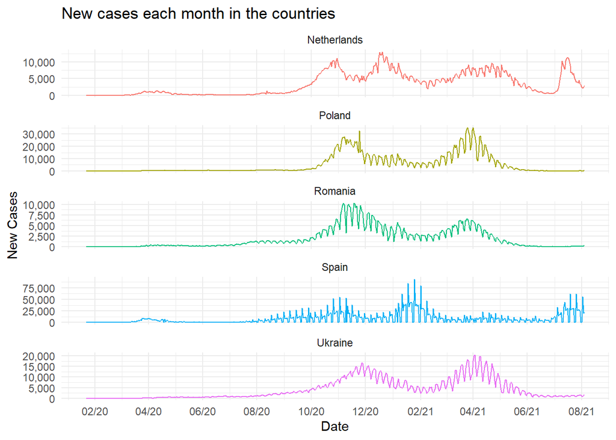

```r
covid_eu %>%
  filter(country %in% c("Spain", "Ukraine", "Poland", "Romania", "Netherlands")) %>%
  ggplot(aes(x = date, y = new.c, color = country)) +
  geom_line(show.legend = TRUE) +
  scale_x_date(date_breaks ="2 month", date_labels ="%m/%y") +
  scale_y_continuous(labels = scales::comma) +
  facet_wrap(~country, ncol = 1, scales = "free_y") +
  labs(x="Date", y="New Cases", title = "New cases each month in the countries") +
  theme_minimal() + guides(color="none")
```

Plot cumulative cases for bottom top10 most populated EU countries:

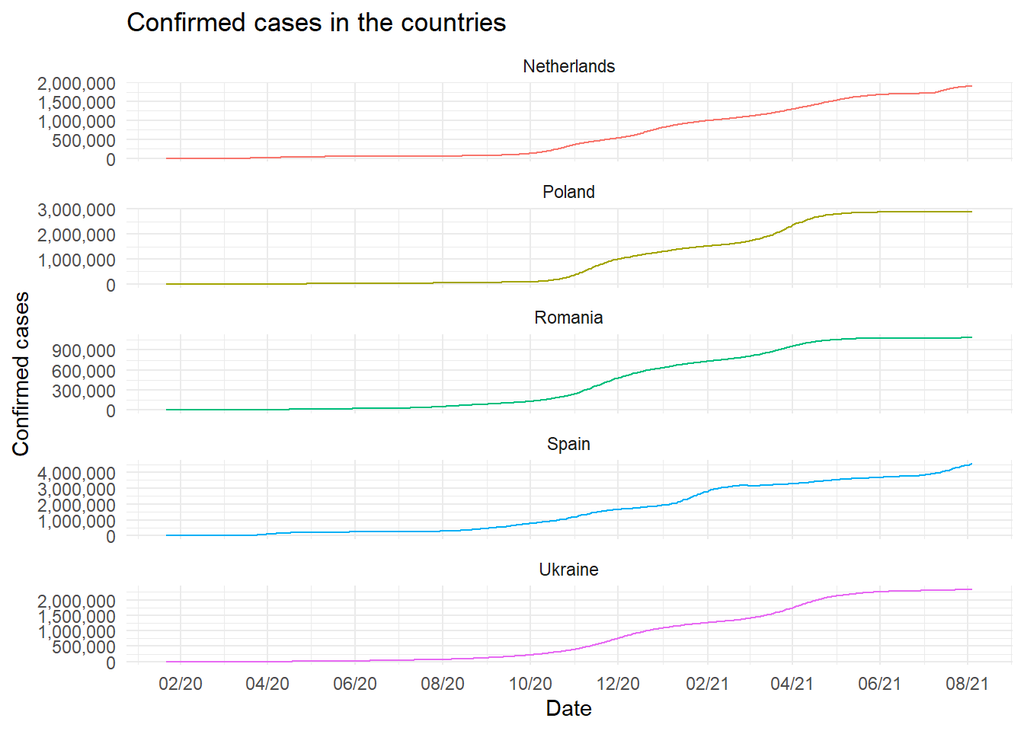

```r
covid_eu %>%
  filter(country %in% c("Spain", "Ukraine", "Poland", "Romania", "Netherlands")) %>%
  ggplot(aes(x = date, y = confirmed, color = country)) +
  geom_line(show.legend = FALSE) +
  scale_x_date(date_breaks = "2 month", date_labels = "%m/%y") +
  scale_y_continuous(labels = scales::comma) +
  facet_wrap(~country, ncol = 1, scales = "free_y") +
  labs(x = "Date", y = "Confirmed cases", title = "Confirmed cases in the countries") +
  theme_minimal() + guides(color="none")
```

Plot new deaths for bottom top10 most populated EU countries:

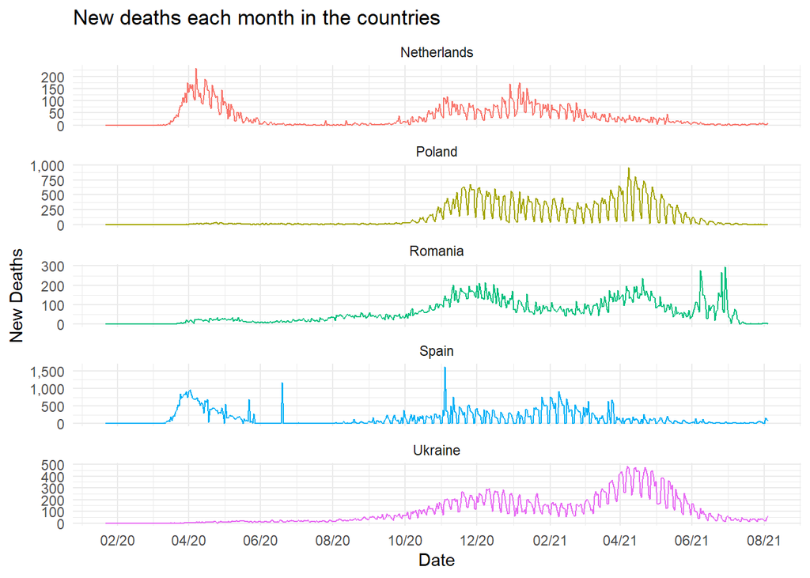

```r
covid_eu %>%
  filter(country %in% c("Spain", "Ukraine", "Poland", "Romania", "Netherlands")) %>%
  ggplot(aes(x = date, y = new.d, color = country)) +
  geom_line(show.legend = FALSE) +
  scale_x_date(date_breaks = "2 month", date_labels = "%m/%y") +
  scale_y_continuous(labels = scales::comma) +
  facet_wrap(~country, ncol = 1, scales = "free_y") +
  labs(x = "Date", y = "New Deaths", title = "New deaths each month in the countries") +
  theme_minimal() + guides(color="none")
```